# cen_fsus group project

Over time and geographical space, it has been shown various times that divorce rate differs reagrding education social class and income. The higher educated and the higher the social class the lower the divorce rate. A the divorce rate in the UK has sunk by 34% in the last ten years, we want to evaluate if this purposes still hold (Office for National Statistics).

Social grade, a measure developped by the “National Readership Survey” should represent social class and income (It has been shown that social grade and income correlate highly). It is classified as follows:

A Higher managerial, administrative and professional  
B Intermediate managerial, administrative and professional  
C1 Supervisory, clerical and junior managerial, administrative and professional  
C2 Skilled manual workers  
D Semi-skilled and unskilled manual workers E State pensioners, casual and lowest grade workers, unemployed with state benefits only

In the original census data the social grades were grouped (AB, C1, C2, DE) and studends as well as people over 64 years old do not have a social grade and are therefore not included in the analysis.

The variable “Education” represents the highest degree people achieved. Holder of non-british awards were not classified in the original data and therefore not included in the analysis.

Between education and social grade is a middle strong linear correlation. The higher the education level the higher the social grade. Still it is insightful to look at both variables alone and combined, as they give different insights.

```r
#quick look at distributions
table(cen_f$separated)
```

```
##
##      0      1
## 749952 205218
```

```r
addmargins(prop.table(table(cen_f$separated)))
```

```
##
##         0         1       Sum
## 0.7851503 0.2148497 1.0000000
```

```r
table(cen_f$education)
```

```
##
##     10     11     12     13     14     15
## 162768 150725 153917  37220 117626 332914
```

```r
prop.table(table(cen_f$education))
```

```
##
##         10         11         12         13         14         15
## 0.17040736 0.15779914 0.16114095 0.03896689 0.12314666 0.34853900
```

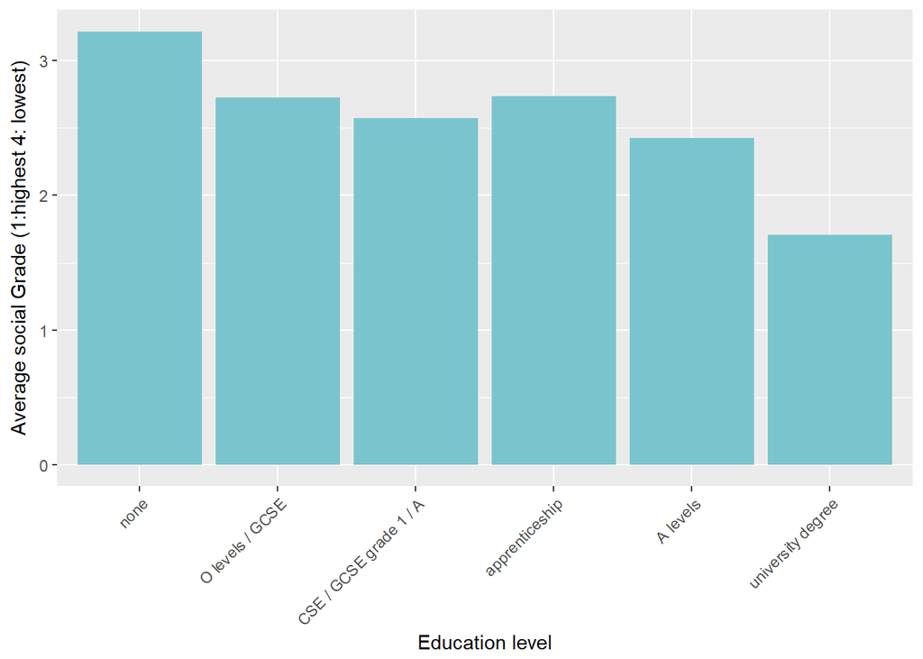

```r
#correlate independend variables
library(ggplot2)
library(dplyr)
social_plot <- ggplot(cen_f, aes(x = factor(education), y = social_grade))
social_plot +
  geom_histogram(stat = "summary", fun.y = "mean", fill = "cadetblue3") +
  xlab ("Education level") +
  ylab("Average social Grade (1:highest 4: lowest)") +
  scale_x_discrete(labels = c("10" = "none", "11" = "O levels / GCSE", "12" = "CSE / GCSE grade 1 / A", "13" = "apprenticeship", "14" = "A levels", "15" = "university degree")) +
  theme(axis.text.x = element_text(angle = 45, hjust = 1))
```

```r
cen_f %>% group_by(education) %>% summarise(n = n(), mean_grade = mean(social_grade, na.rm = TRUE))
```

```
## # A tibble: 6 x 3
##   education      n mean_grade
##       <int>  <int>      <dbl>
## 1        10 162768   3.216314
## 2        11 150725   2.725858
## 3        12 153917   2.572179
## 4        13  37220   2.733557
## 5        14 117626   2.425510
## 6        15 332914   1.708339
```

```r
#Spearmans ran correlation coefficient (cor between two comparative variables)
cor(cen_f$social_grade, cen_f$education, method = "spearman", use="p")
```

```
## [1] -0.4973118
```

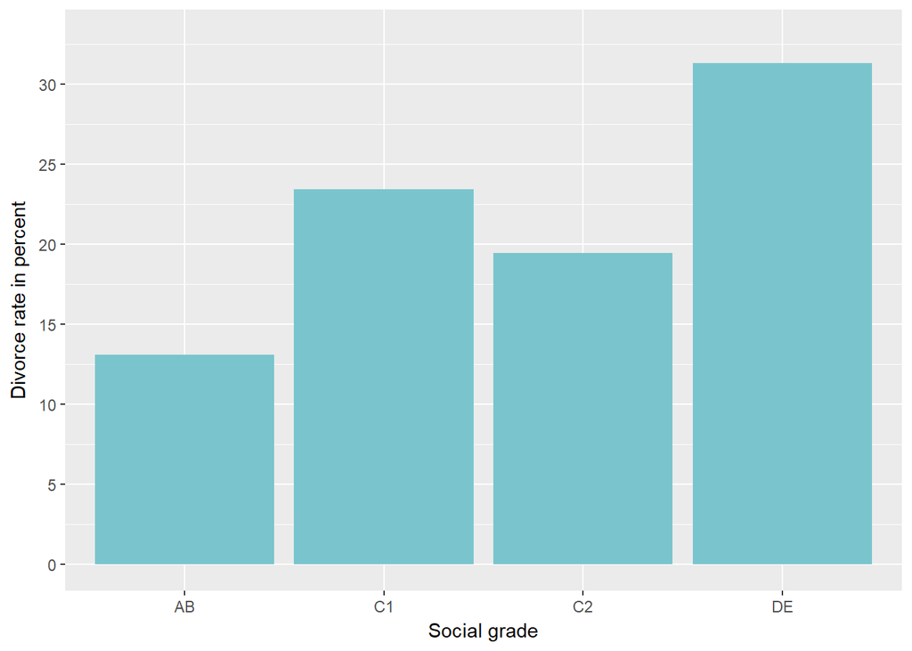

http://digital.nhs.uk/catalogue/PUB15943 http://onlinelibrary.wiley.com/doi/10.1111/j.1741-3737.2012.00977.x/full